# Uma Análise Exploratória do Projeto Ensino Médio e Além (HS&B)

#### 4.1.5. Análise descritiva sobre gênero, tipo de programa e disciplinas de humanidades e ciências

O gráfico da **Figura 5** busca oferecer uma análise entre as médias das disciplinas de humanidades (estudos sociais) e a média de ciências naturais (biologia, química e física) subdivididas por gênero e tipo de currículo escolar (programa).

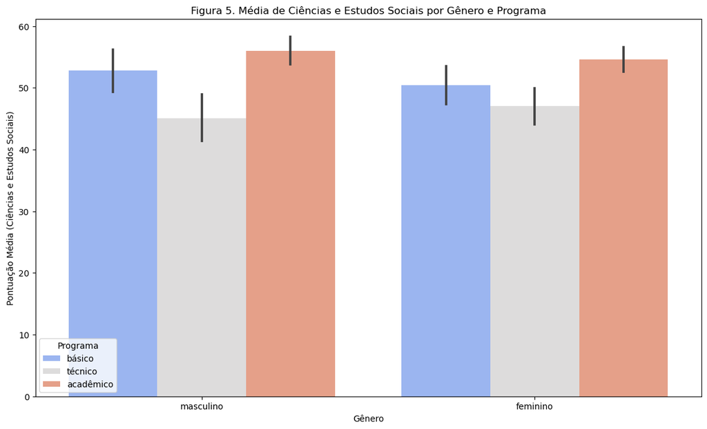

```python
# Gráfico 5: Gênero x Programa x Ciências e Estudos Sociais
df['ciencias_estsociais'] = (df['ciencias'] + df['estsociais']) / 2
plt.figure(figsize=(14, 8))
sns.barplot(data=df, x='genero', y='ciencias_estsociais', hue='programa', palette="coolwarm")
plt.title('Figura 5. Média de Ciências e Estudos Sociais por Gênero e Programa')
plt.xlabel('Gênero')
plt.ylabel('Pontuação Média (Ciências e Estudos Sociais)')
plt.legend(title='Programa')
plt.show()
```

#### 4.1.6. Comparação Geral por Classe Social e Programa

O gráfico da **Figura 6** busca estabelecer uma análise comparando as médias dos alunos por classe social e por tipo de currículo escolar.

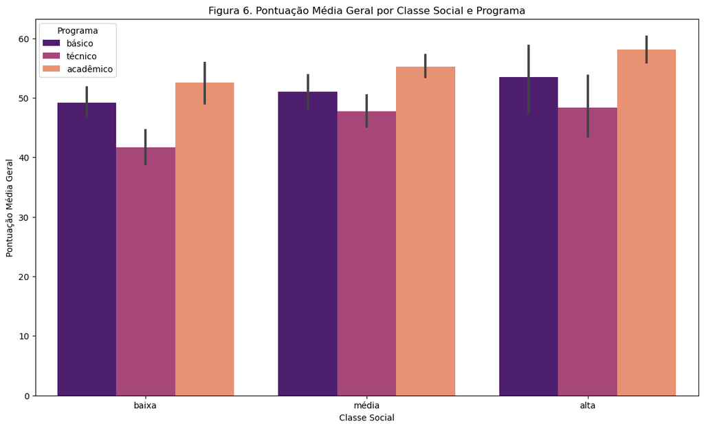

```python
# Gráfico 6: Comparação Geral por Classe Social e Programa
df['pontuacao_total'] = (df['ler'] + df['escrever'] + df['matematica'] + df['ciencias'] + df['estsociais']) / 5
plt.figure(figsize=(14, 8))
sns.barplot(data=df, x='clasocial', y='pontuacao_total', hue='programa', palette="magma")
plt.title('Figura 6. Pontuação Média Geral por Classe Social e Programa')
plt.xlabel('Classe Social')
plt.ylabel('Pontuação Média Geral')
plt.legend(title='Programa')
plt.show()
```